# Comparing Statistical Distributions App

February 2, 2020

## Introduction

This simple app allows statistics students to grasp differences and similarities between some discrete and continuous statistical distributions, their parameters, and test the assumptions for the approximations between them.

The app can be accessed using [this link](https://leandrozappani.shinyapps.io/comparing_statistical_distributions/).  
The ui.R and server.R files are available at this [github repository](https://github.com/leandrozappani/developing_data_products_coursera).

## General View

As you can see, in the side panel there are a number of slides and boxes to tweak, and in the bottom part there are some instructions.

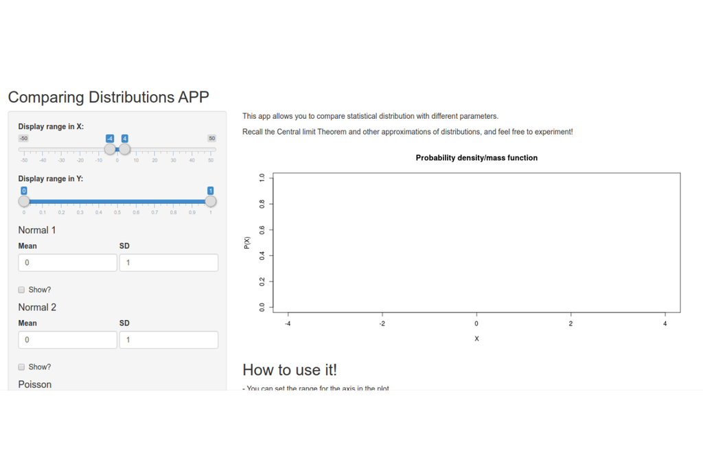

And in the bottom part there are some instructions.

The app basically uses the base functions for probability density/mass functions `dnorm`, `dt`, `dpois` and `dbinom` with the custom parameters selected in the side bar. The computation is similar as what follows:

```r
x <- -5:5
px <- dnorm(x, mean = 0, sd = 1)
head(cbind(x,px))
```

```
##       x           px
## [1,] -5 1.486720e-06
## [2,] -4 1.338302e-04
## [3,] -3 4.431848e-03
## [4,] -2 5.399097e-02
## [5,] -1 2.419707e-01
## [6,]  0 3.989423e-01
```

The second step is to plot these values as a line.

## Example of usage

One approximation learned in introductory statistics is that with large n and probability of success close to 0.5, the binomial distribution can be approximated by a normal distribution.

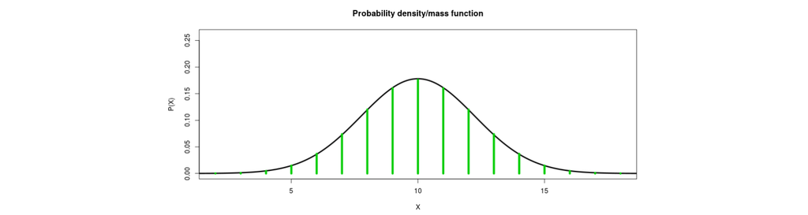

In this example, the parameters for the binomial are \(p=0.5\) and \(n=20\), so the mean is \(\overline x =p n=10\) and standard deviation is \(s= \sqrt{p(1-p) n }\approx 2.24\). When we tweak the normal parameters accordingly, the distributions match.